# Communicate Data Findings for the dataset 'Ford GoBike System Data'

## by Ekaterina Litvinova

## Investigation Overview

In this analysis, the main interest is the data associated with the user, as well as the features associated with the movement of the users. I find it useful for business to have an information about the most popular stations, user routes, and the hours and days of the week when users are most active in rental.

## Dataset Overview

The data for this dataset was downloaded from Udacity. The data set includes information about individual rides made in a bike-sharing system in February, 2019. The total amount of data items (rides) in the dataset after cleaning all incorrect data is 174952.

## The percentages of the user type in our dataset

We can see that a huge part is occupied by **Subscriber users: 90.5%** and only **9.5% are Customer users**

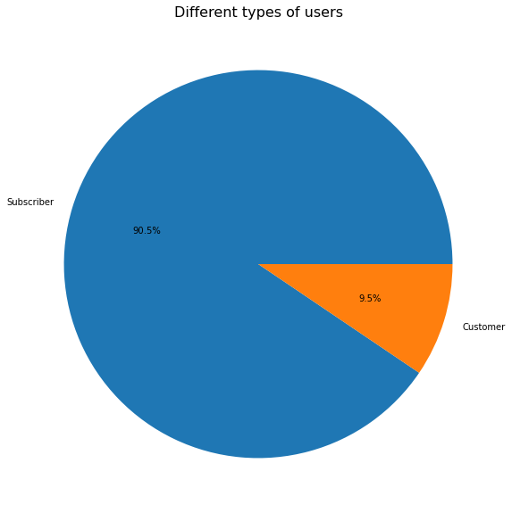

## Top 20 most common user ages

We can see that the leading position in the Top 20 most common user ages belongs to users **aged 31**.

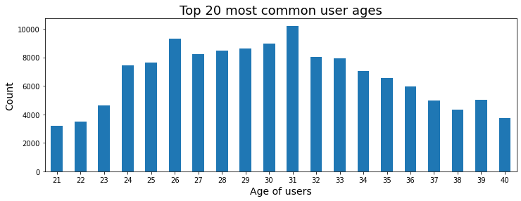

## Top 10 most popular starting stations

And the leading position in the list of 10 most popular starting stations is occupied by a station called **'Market St at 10th St'** with a сount of 3649.

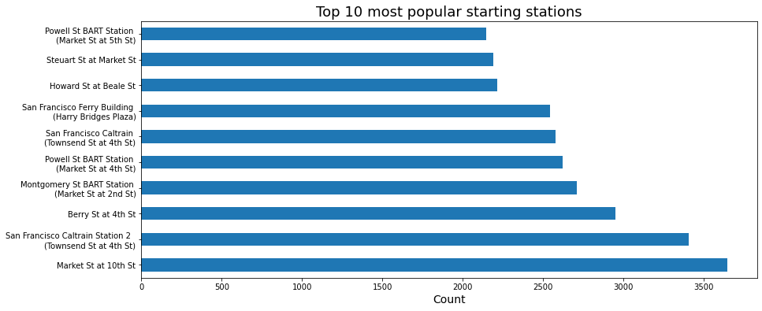

## Average travel time of users by type (Subscriber/Customer)

Now we can make a conclusion that Subscribers usually use bicycles for much shorter trips than Customers.

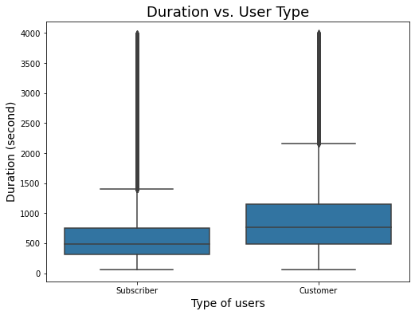

## Count of rides by hour, weekday by user type

So now on the first graph we can see that regardless of the user type the most popular time is to pick up the bike is around 8 and 17 o'clock. Based on this we can conclude that majority of rides is to and from the office (or work place).  
On the second graph there's also a similar distribution between two user types and the busiest day is Thursday, which is quite unexpected.

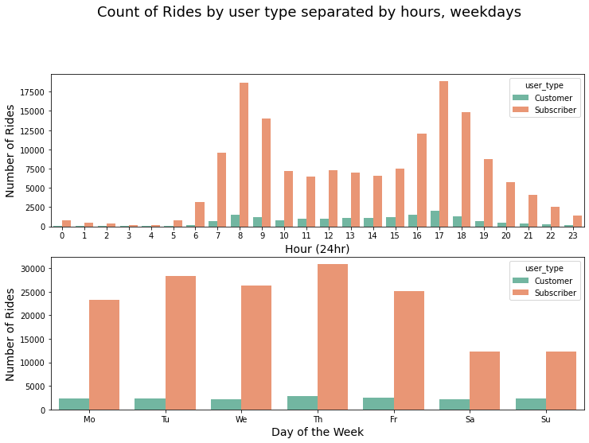

## Top 10 of the most popular routes used by users

We can see that the most popular route is from **'Berry St at 4th St'** to **'San Francisco Ferry Building (Harry Bridges Plaza)'** with the count of 327 rides.

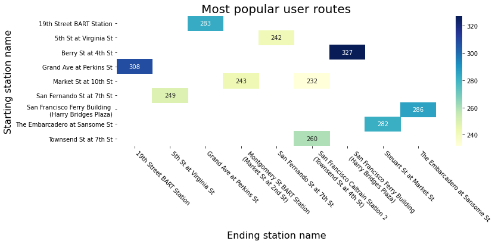

## The relationship of the length of the journey with the age of the user by dividing the users into categories

Based on the graph we can conclude that in general there's more longer trips in 'Customer' category than in 'Subscribers category. We also observed this on a boxplot previously. However, in the age group of 20 - 30 years 'Subscribers' have slightly more long trips than 'Customers'.

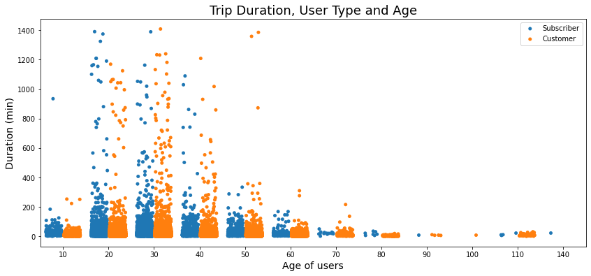

## The relationship between the duration of the journey and the start time of the journey with the division of users into categories.

This graph provides some interesting information about relationships between trip duration, start hour and user category. At first, we can conclude that there's almost no difference in behaviour between Customers and Subscribers here. Then, we can see that most of the trips with duration between 4 - 10 hours (or 240 - 600 minutes) start between 8 and 10 in the morning. Lastly, the longest trips (over 15 hours or 900 minutes) mostly happen in the second half of the day.

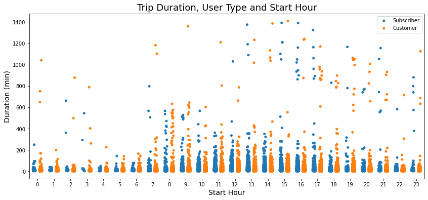